# Dimensionality reduction

This week we analyse the “Human” dataset. In short, it includes human development indicators (columns) from countries (rows). See more: http://hdr.undp.org/en/content/human-development-index-hdi

```r
library(purrr)
library(ggplot2)
library(tidyr)
library(skimr)
human <- read.csv("~/IODS-project/data/human.csv", row.names=1)
```

## EDA Exploring the dataset

```r
skim(human)
```

```
## Skim summary statistics
##  n obs: 155
##  n variables: 8
##
## -- Variable type:integer -----------------------------------------------------------------------------------------------------------
##  variable missing complete   n     mean       sd  p0    p25   p50   p75
##       gni       0      155 155 17627.9  18543.85 581 4197.5 12040 24512
##    matmor       0      155 155   149.08   211.79   1   11.5    49   190
##    p100     hist
##  123124 ▇▃▂▁▁▁▁▁
##    1100 ▇▁▁▁▁▁▁▁
##
## -- Variable type:numeric -----------------------------------------------------------------------------------------------------------
##     variable missing complete   n  mean    sd    p0   p25   p50   p75
##        birth       0      155 155 47.16 41.11  0.6  12.65 33.6  71.95
##  edu2FMratio       0      155 155  0.85  0.24  0.17  0.73  0.94  1
##          eye       0      155 155 13.18  2.84  5.4  11.25 13.5  15.2
##   labFMratio       0      155 155  0.71  0.2   0.19  0.6   0.75  0.85
##           le       0      155 155 71.65  8.33 49    66.3  74.2  77.25
##       repinp       0      155 155 20.91 11.49  0    12.4  19.3  27.95
##    p100     hist
##  204.8  ▇▅▃▂▁▁▁▁
##    1.5  ▁▂▂▂▇▃▁▁
##   20.2  ▁▂▃▆▇▇▂▁
##    1.04 ▁▂▁▃▅▇▇▂
##   83.5  ▂▁▃▃▅▇▇▇
##   57.5  ▂▇▇▅▃▃▁▁
```

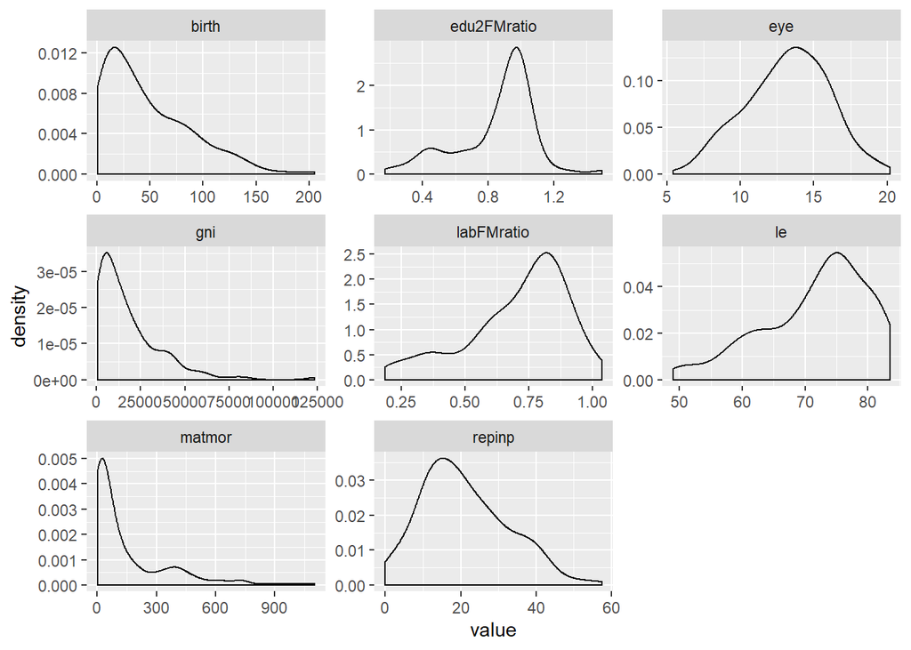

```r
human %>% keep(is.numeric) %>% gather() %>%
  ggplot(aes(value)) + facet_wrap(~ key, scales = "free") + geom_density()
```

Our wrangled slice of the Human dataset includes 8 variables, all numerical.

```r
# correlation plot
library(tidyverse)
library(corrplot)
cor_matrix <- cor(human)
cor_matrix %>% round(2)
```

```
##             edu2FMratio labFMratio   eye    le   gni matmor birth repinp
## edu2FMratio        1.00       0.01  0.59  0.58  0.43  -0.66 -0.53   0.08
## labFMratio         0.01       1.00  0.05 -0.14 -0.02   0.24  0.12   0.25
## eye                0.59       0.05  1.00  0.79  0.62  -0.74 -0.70   0.21
## le                 0.58      -0.14  0.79  1.00  0.63  -0.86 -0.73   0.17
## gni                0.43      -0.02  0.62  0.63  1.00  -0.50 -0.56   0.09
## matmor            -0.66       0.24 -0.74 -0.86 -0.50   1.00  0.76  -0.09
## birth             -0.53       0.12 -0.70 -0.73 -0.56   0.76  1.00  -0.07
## repinp             0.08       0.25  0.21  0.17  0.09  -0.09 -0.07   1.00
```

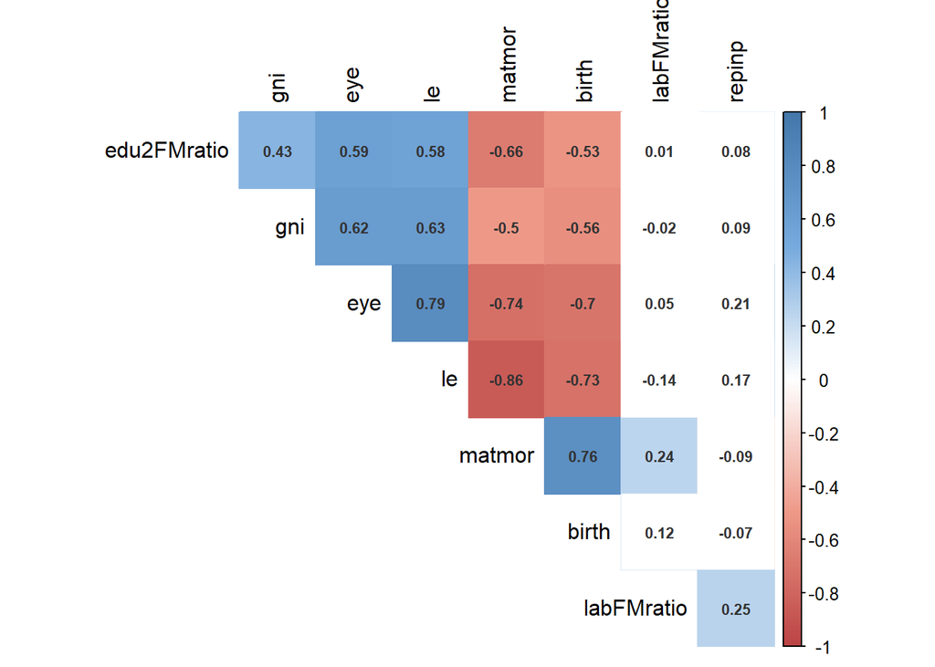

```r
# significance tests for corr matrix
res <- cor.mtest(human, conf.level = .95)
# draw the corrplot with sig levels
col <- colorRampPalette(c("#BB4444", "#EE9988", "#FFFFFF", "#77AADD", "#4477AA"))
corrplot(cor_matrix, method = "color", col = col(200),
         type = "upper", order = "hclust", number.cex = .7,
         addCoef.col = "grey20", # Add coefficient of correlation
         tl.col = "black", tl.srt = 90, # Text label color and rotation
         # Combine with significance, set visible sig level
         p.mat = res$p, sig.level = 0.01, insig = "blank",
         # hide correlation coefficient on the principal diagonal
         diag = FALSE)
```

Maternal mortality and Adolescence birth rate have high negative correlations with other indicators, excluding the variables labFMratio and repinp. Variables gni, eye, le and edu2fmratio are all positively correlated with each other.

## Principal Component Analysis

First PCA with non-standardized data

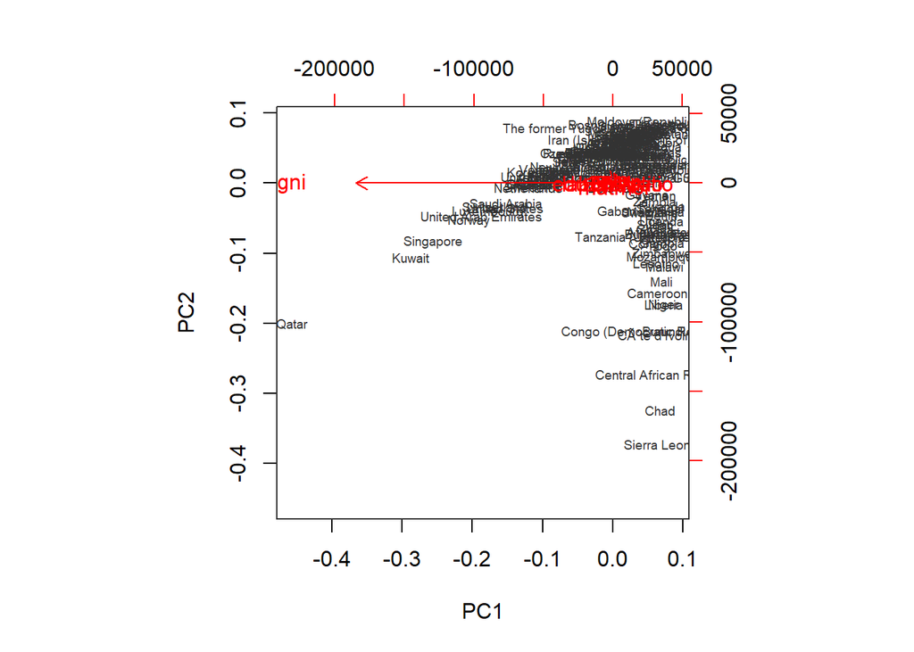

```r
pca_human1 <- prcomp(human)
biplot(pca_human1, choices = 1:2, cex = c(0.6, 1), col = c("grey20", "red"))
```

Second PCA with stardardized variables

```r
# scale the variables
human_std <- scale(human)
# run PCA, round the results
pca_human2 <- prcomp(human_std)
s <- summary(pca_human2)
pca_pr <- round(100*s$importance[2, ], digits = 1)
pca_pr
```

```
##  PC1  PC2  PC3  PC4  PC5  PC6  PC7  PC8
## 53.6 16.2  9.6  7.6  5.5  3.6  2.6  1.3
```

The figures show how much of the variance of all variables each principal component explain.

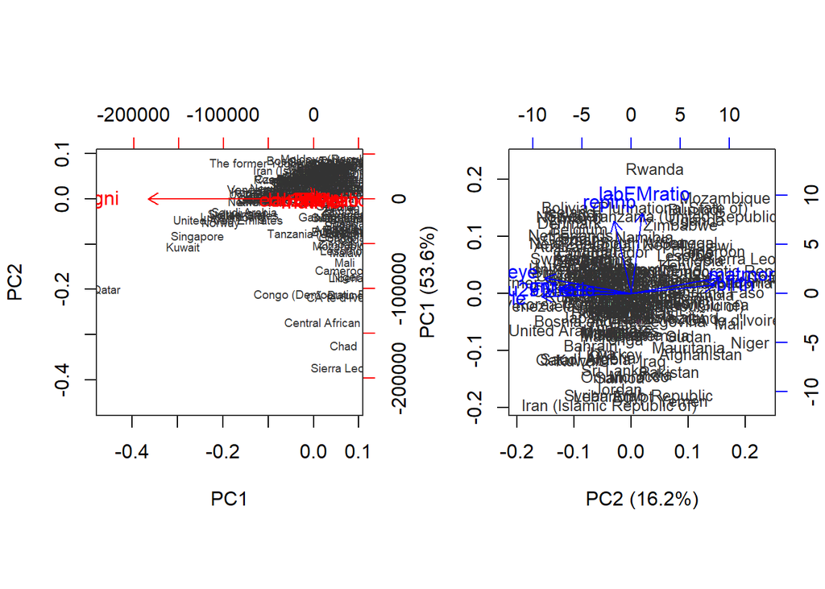

```r
# create object pc_lab to be used as axis labels
pc_lab <- paste0(names(pca_pr), " (", pca_pr, "%)")
# draw a biplot
par(mfrow = c(1,2))
biplot(pca_human1, choices = 1:2, cex = c(0.6, 1), col = c("grey20", "red"))
biplot(pca_human2, xlab = pc_lab[2], ylab = pc_lab[1], choices = 1:2, cex = c(0.8, 1), col = c("grey20", "blue"))
```

Standardized data: Like we saw from the correlation plot, maternal mortality and adolescent birth rate are highly related. In the biplot, if the arrows are close to one another, variables have high correlation.

The first principal component (PC1) simplifies the picture as follows: There is a continuum, where in another end there are countries with high maternal mortality and adolescent birth rate, and in the opposite end high life expectancy, more years in education, and better F/M ratio in secondary education.

**Interpretation of components**

The first principal component (PC1) reflects the overall health and gender equality in the private sphere.

The second principal component (PC2) reflects gender equality in the public sphere. The higher the value of PC2, the higher the F/M ratio in labour and women representatives in parliament.

## MCA, Multiple Correspondence Analysis

Using the Tea dataset from Factominer.

```r
library(FactoMineR)
data(tea)
dim(tea)
```

```
## [1] 300  36
```

```r
str(tea)
```

```
## 'data.frame':    300 obs. of  36 variables:
##  $ breakfast       : Factor w/ 2 levels "breakfast","Not.breakfast": 1 1 2 2 1 2 1 2 1 1 ...
##  $ tea.time        : Factor w/ 2 levels "Not.tea time",..: 1 1 2 1 1 1 2 2 2 1 ...
##  $ evening         : Factor w/ 2 levels "evening","Not.evening": 2 2 1 2 1 2 2 1 2 1 ...
##  $ lunch           : Factor w/ 2 levels "lunch","Not.lunch": 2 2 2 2 2 2 2 2 2 2 ...
##  $ dinner          : Factor w/ 2 levels "dinner","Not.dinner": 2 2 1 1 2 1 2 2 2 2 ...
##  $ always          : Factor w/ 2 levels "always","Not.always": 2 2 2 2 1 2 2 2 2 2 ...
##  $ home            : Factor w/ 2 levels "home","Not.home": 1 1 1 1 1 1 1 1 1 1 ...
##  $ work            : Factor w/ 2 levels "Not.work","work": 1 1 2 1 1 1 1 1 1 1 ...
##  $ tearoom         : Factor w/ 2 levels "Not.tearoom",..: 1 1 1 1 1 1 1 1 1 2 ...
##  $ friends         : Factor w/ 2 levels "friends","Not.friends": 2 2 1 2 2 2 1 2 2 2 ...
##  $ resto           : Factor w/ 2 levels "Not.resto","resto": 1 1 2 1 1 1 1 1 1 1 ...
##  $ pub             : Factor w/ 2 levels "Not.pub","pub": 1 1 1 1 1 1 1 1 1 1 ...
##  $ Tea             : Factor w/ 3 levels "black","Earl Grey",..: 1 1 2 2 2 2 2 1 2 1 ...
##  $ How             : Factor w/ 4 levels "alone","lemon",..: 1 3 1 1 1 1 1 3 3 1 ...
```

[output cut: 22 more lines]

```r
# select columns 1:8,13,19:25
tea_time <- tea[,c(1:8,13,19:25)]
str(tea_time)
```

```
## 'data.frame':    300 obs. of  16 variables:
##  $ breakfast       : Factor w/ 2 levels "breakfast","Not.breakfast": 1 1 2 2 1 2 1 2 1 1 ...
##  $ tea.time        : Factor w/ 2 levels "Not.tea time",..: 1 1 2 1 1 1 2 2 2 1 ...
##  $ evening         : Factor w/ 2 levels "evening","Not.evening": 2 2 1 2 1 2 2 1 2 1 ...
##  $ lunch           : Factor w/ 2 levels "lunch","Not.lunch": 2 2 2 2 2 2 2 2 2 2 ...
##  $ dinner          : Factor w/ 2 levels "dinner","Not.dinner": 2 2 1 1 2 1 2 2 2 2 ...
##  $ always          : Factor w/ 2 levels "always","Not.always": 2 2 2 2 1 2 2 2 2 2 ...
##  $ home            : Factor w/ 2 levels "home","Not.home": 1 1 1 1 1 1 1 1 1 1 ...
##  $ work            : Factor w/ 2 levels "Not.work","work": 1 1 2 1 1 1 1 1 1 1 ...
##  $ Tea             : Factor w/ 3 levels "black","Earl Grey",..: 1 1 2 2 2 2 2 1 2 1 ...
##  $ age             : int  39 45 47 23 48 21 37 36 40 37 ...
##  $ sex             : Factor w/ 2 levels "F","M": 2 1 1 2 2 2 2 1 2 2 ...
##  $ SPC             : Factor w/ 7 levels "employee","middle",..: 2 2 4 6 1 6 5 2 5 5 ...
##  $ Sport           : Factor w/ 2 levels "Not.sportsman",..: 2 2 2 1 2 2 2 2 2 1 ...
##  $ age_Q           : Factor w/ 5 levels "15-24","25-34",..: 3 4 4 1 4 1 3 3 3 3 ...
##  $ frequency       : Factor w/ 4 levels "1/day","1 to 2/week",..: 1 1 3 1 3 1 4 2 3 3 ...
##  $ escape.exoticism: Factor w/ 2 levels "escape-exoticism",..: 2 1 2 1 1 2 2 2 2 2 ...
```

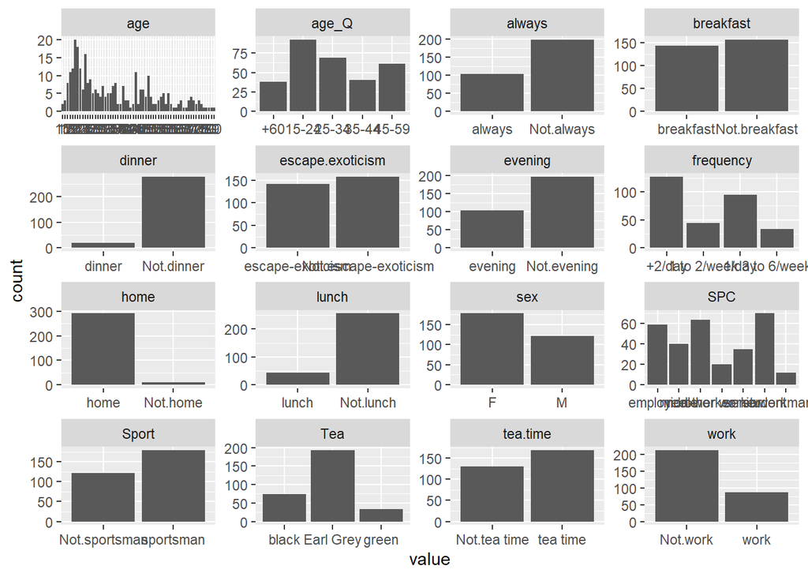

```r
gather(tea_time) %>% ggplot(aes(value)) + geom_bar() + facet_wrap("key", scales = "free")
```

```r
# run MCA
# supplementary variables, var10 is age and numerical, var 11-16 chosen as categorical supplements (not included in creating the dimensions, but help in interpreting them)
mca <- MCA(tea_time, quanti.sup = 10, quali.sup = 11:16, graph = FALSE)
summary(mca)
```

```
##
## Call:
## MCA(X = tea_time, quanti.sup = 10, quali.sup = 11:16, graph = FALSE)
##
##
## Eigenvalues
##                        Dim.1   Dim.2   Dim.3   Dim.4   Dim.5   Dim.6
## Variance               0.177   0.147   0.128   0.122   0.110   0.101
## % of var.             15.960  13.250  11.504  10.997   9.860   9.077
## Cumulative % of var.  15.960  29.209  40.713  51.711  61.570  70.647
##                        Dim.7   Dim.8   Dim.9  Dim.10
## Variance               0.097   0.087   0.079   0.063
## % of var.              8.685   7.871   7.111   5.686
## Cumulative % of var.  79.332  87.203  94.314 100.000
##
## Individuals (the 10 first)
##                  Dim.1    ctr   cos2    Dim.2    ctr   cos2    Dim.3
## 1             |  0.196  0.072  0.048 | -0.605  0.830  0.461 | -0.168
## 2             |  0.196  0.072  0.048 | -0.605  0.830  0.461 | -0.168
## 3             |  0.245  0.113  0.026 |  0.382  0.331  0.064 |  0.100
## 4             |  0.980  1.806  0.488 |  0.192  0.084  0.019 | -0.152
## 5             | -0.053  0.005  0.003 |  0.250  0.142  0.076 |  0.060
## 6             |  0.980  1.806  0.488 |  0.192  0.084  0.019 | -0.152
## 7             | -0.136  0.035  0.040 | -0.327  0.243  0.233 | -0.195
## 8             | -0.002  0.000  0.000 | -0.384  0.335  0.169 |  0.561
## 9             | -0.136  0.035  0.040 | -0.327  0.243  0.233 | -0.195
## 10            |  0.082  0.013  0.007 | -0.485  0.533  0.248 |  0.307
##                  ctr   cos2
## 1              0.074  0.036 |
## 2              0.074  0.036 |
## 3              0.026  0.004 |
## 4              0.060  0.012 |
## 5              0.009  0.004 |
## 6              0.060  0.012 |
## 7              0.099  0.082 |
## 8              0.820  0.359 |
## 9              0.099  0.082 |
## 10             0.245  0.099 |
##
## Categories (the 10 first)
```

[output cut: 56 more lines]

```
## workman        0.003 -0.973 |
## Not.sportsman  0.003 -0.984 |
##
## Supplementary categorical variables (eta2)
##                    Dim.1 Dim.2 Dim.3
## sex              | 0.044 0.000 0.000 |
## SPC              | 0.039 0.071 0.025 |
## Sport            | 0.003 0.006 0.003 |
## age_Q            | 0.019 0.102 0.035 |
## frequency        | 0.103 0.040 0.045 |
## escape.exoticism | 0.000 0.000 0.001 |
##
## Supplementary continuous variable
##                  Dim.1    Dim.2    Dim.3
## age           |  0.009 | -0.292 |  0.042 |
```

Supplementary variables do not contribute to the dimensions (not included in the model), but correspondingly we can see how they are linked to dimensions.

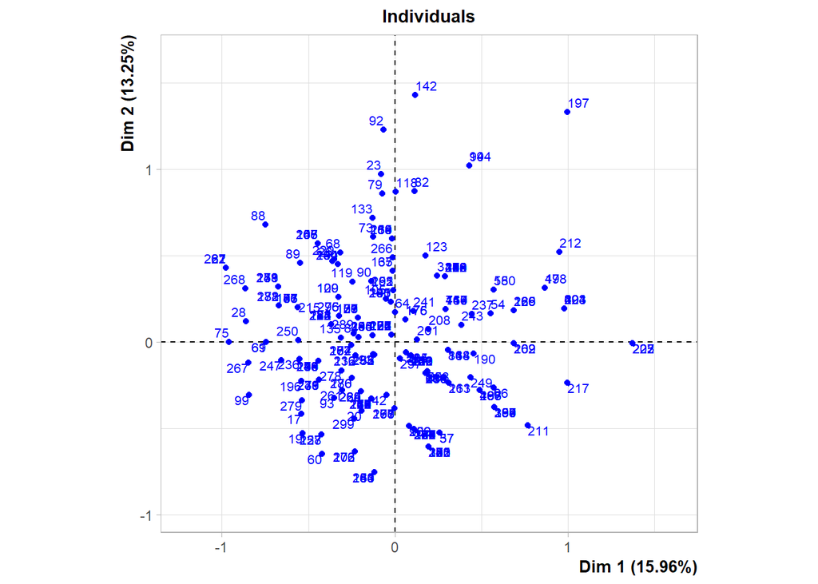

```r
par (mfrow = c(2,2))
plot.MCA(mca, invisible=c("var","quali.sup"), cex=0.7, title="Individuals")
```

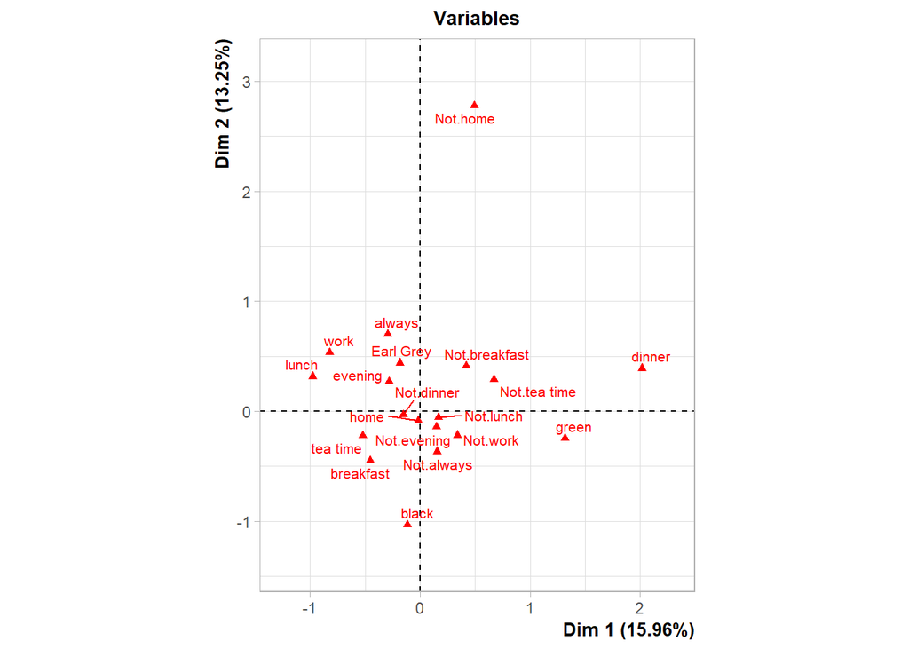

```r
plot.MCA(mca, invisible=c("ind","quali.sup"), cex=0.7, title="Variables")
```

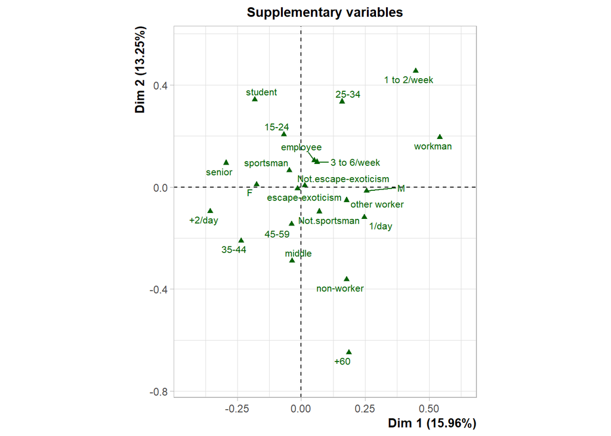

```r
plot.MCA(mca, invisible=c("ind", "var"), cex=0.7, title="Supplementary variables")
```

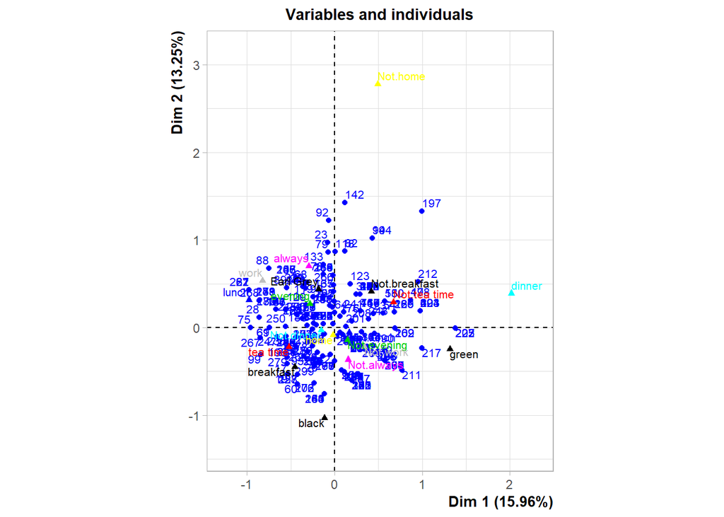

```r
plot.MCA(mca, invisible=c("quali.sup"), cex=0.7, habillage = "quali", title="Variables and individuals")
```

```r
# habillage = "quali" means one color is used for each categorical variables;
```

It is possible to plot the individuals and variables in different and in the same plot. From the plot we can see which variables define the dimensions. Distance from the origo represents power.

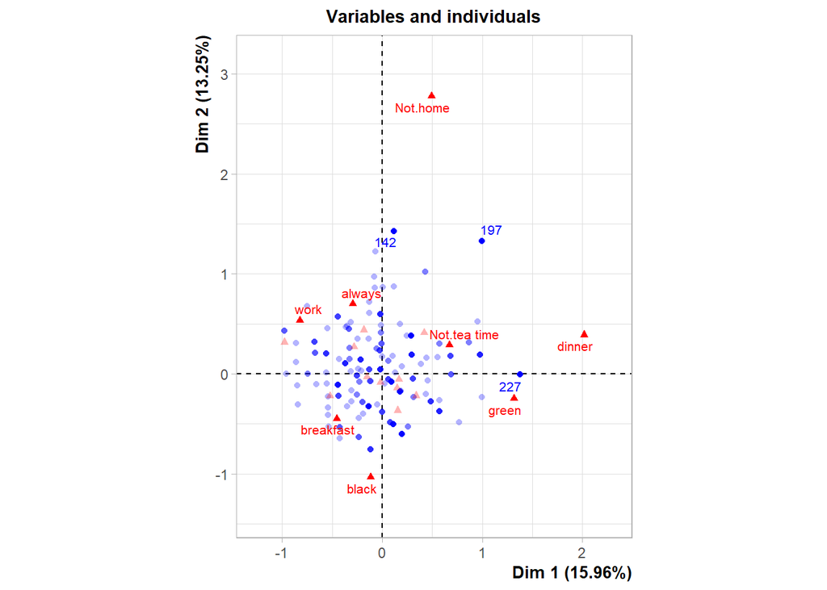

```r
# SelectMod="contrib 8" displays 8 variables with highest contribution to the dimensions
# select = "contrib 3" shows the labels of 3 individuals that contribute the most to the dimensions
plot.MCA(mca, invisible=c("quali.sup"), selectMod="contrib 8", select = "contrib 3", cex=0.7, title="Variables and individuals")
```

Here we can see the variables and individuals together. Only those with most contribution have labels to make the plot more readable.

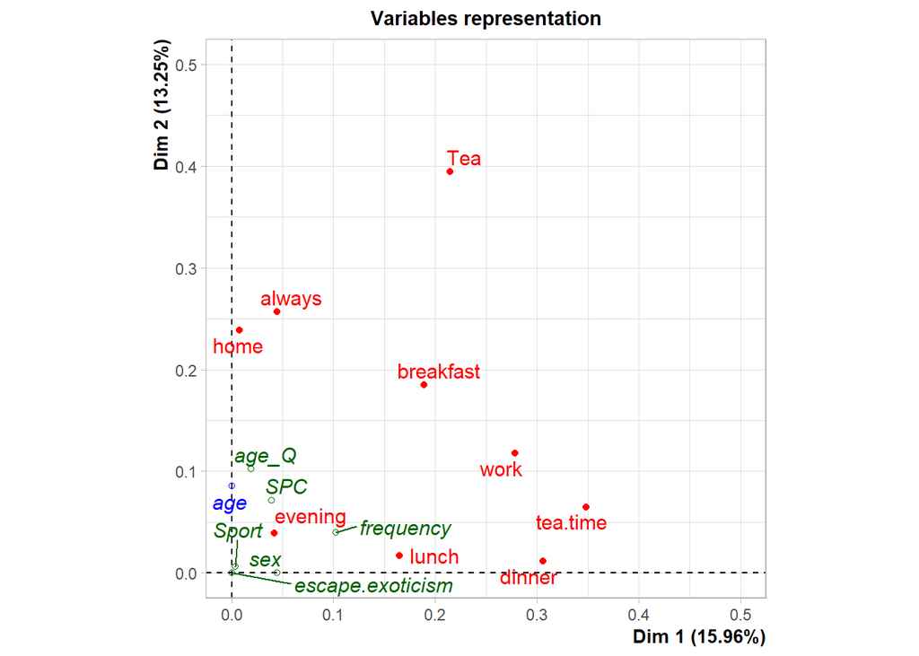

```r
plot.MCA(mca, choix="var", xlim=c(0,0.5), ylim=c(0,0.5))
```

This choix-version of the MCA-plot shows the links between variables and dimensions. The value (for the categorical variables) is the squared correlation ratio between the dimension and the variable. So bigger value means stronger link with the dimension.

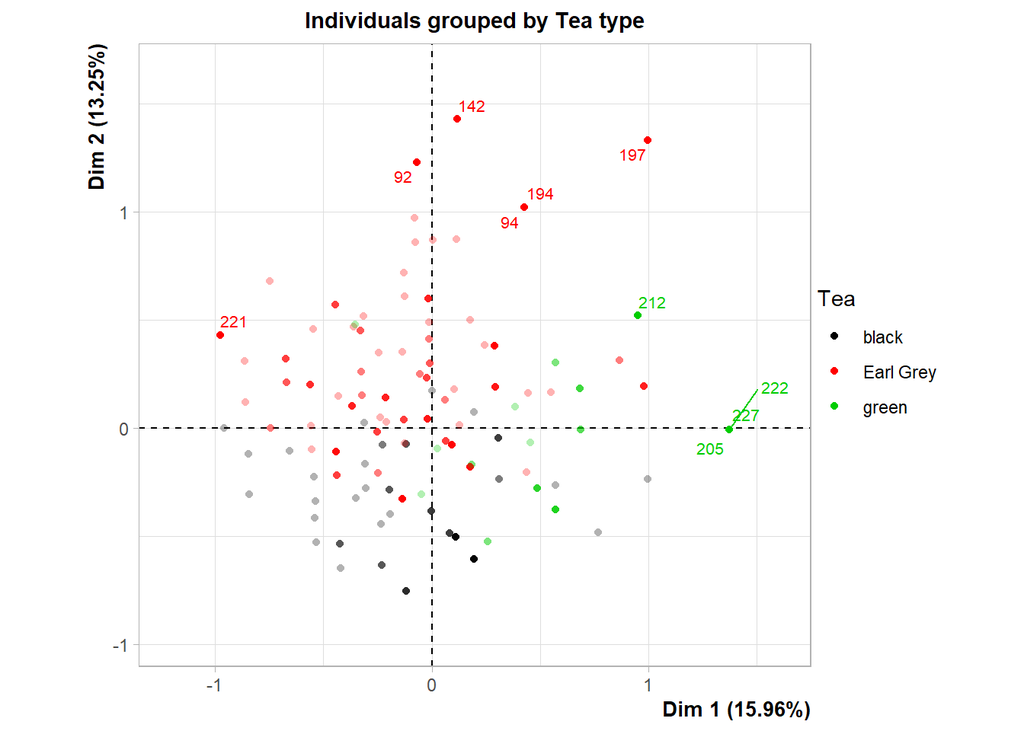

```r
plot.MCA(mca, invisible=c("quali.sup", "var"), select = "contrib 10", habillage = "Tea", cex=0.7, title="Individuals grouped by Tea type")
```